# Bac pro Boulanger-pâtissier - Onisep

# Bac pro Boulanger-pâtissier

Durée de la formation : **3 ans**

Nature de la formation : **Diplôme national ou diplôme d'État**

## Les baccalauréats professionnels

- [**Lire l'article sur** le bac professionnel : études, programme...](https://www.onisep.fr/formation/apres-la-3-la-voie-professionnelle/les-diplomes-de-la-voie-pro/le-bac-professionnel/le-bac-professionnel-etudes-programme)

## Objectifs de la formation

Le cœur de métier des boulangers et pâtissiers est la fabrication de produits sucrés et salés. Ils déterminent les quantités nécessaires de matières premières, choisissent les techniques de fabrication adaptées et soignent la présentation des produits. Le diplômé de bac pro peut être autonome dans l'organisation de l'approvisionnement en matières premières et de la production. Il a acquis des savoir-faire en cuisine et sait confectionner des produits traiteurs (fabrication des pains, des pâtes, des petits fours, des crèmes sauces et coulis, du chocolat de couverture, des produits traiteurs…). Il sait réaliser des cuissons, assembler, décorer, réaliser des finitions. Il a également des compétences en gestion de l'entreprise, commercialisation et animation d'équipe.

Il peut évoluer rapidement vers des postes de responsable de rayon dans la grande distribution, de responsable de production dans l'industrie agroalimentaire ou devenir artisan indépendant.

## Accès à la formation

Ce bac pro se prépare en 3 ans après la classe de 3<sup>e</sup>. Les élèves entrent en 2<sup>de</sup> professionnelle métiers de l'alimentation pour préparer cette spécialité du bac pro.

L'accès est différent pour les élèves en apprentissage qui entrent directement dans cette spécialité de bac pro sans passer par une 2<sup>de</sup> pro famille de métiers.

Les élèves titulaires de certains CAP du même secteur peuvent également le préparer en 2 ans sous certaines conditions.

**Exemples de formations requises :**

- [Classe de 2de professionnelle métiers de l'alimentation](https://www.onisep.fr/ressources/univers-formation/formations/lycees/classe-de-2de-professionnelle-metiers-de-l-alimentation)
- [CAP Boulanger](https://www.onisep.fr/ressources/univers-formation/formations/lycees/cap-boulanger)
- [CAP Chocolaterie-confiserie](https://www.onisep.fr/ressources/univers-formation/formations/lycees/cap-chocolaterie-confiserie)
- [CAP Pâtissier](https://www.onisep.fr/ressources/univers-formation/formations/lycees/cap-patissier)

## Poursuites d'études

Le bac pro a pour premier objectif l'insertion professionnelle mais il est possible de poursuivre des études en 1 an en CS (certificat de spécialisation) ou en 2 ans en brevet professionnel ou en brevet de maîtrise pour s'installer à son compte.

**Exemple(s) de formation(s) :**

- [MC (futur CS) techniques du tour en boulangerie et en pâtisserie](https://www.onisep.fr/ressources/univers-formation/formations/lycees/mc-futur-cs-techniques-du-tour-en-boulangerie-et-en-patisserie)
- [BP Boulanger](https://www.onisep.fr/ressources/univers-formation/formations/lycees/bp-boulanger)
- [BM boulanger](https://www.onisep.fr/ressources/univers-formation/formations/post-bac/bm-boulanger)
- [BM pâtissier chocolatier confiseur glacier traiteur](https://www.onisep.fr/ressources/univers-formation/formations/post-bac/bm-patissier-chocolatier-confiseur-glacier-traiteur)

## Où se former ?

Résultats de recherche

[output not shown]

## Pour aller plus loin

### Exemples de métiers

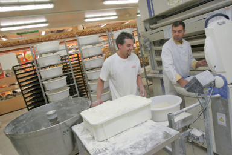

**Boulanger**

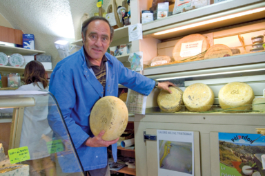

**Commerçant en alimentation**

[figure not shown]

**Opérateur de fabrication de produits alimentaires**

[figure not shown]

**Pâtissier**

### À lire aussi

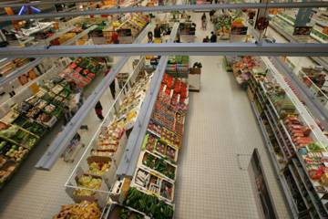

Dossier

**Commerce, distribution**

[figure not shown]

Article

**Qu'est-ce que la voie pro ?**

[figure not shown]

Article

**Les élèves en situation de handicap au lycée**

[figure not shown]

Article

**Après le bac : les différentes poursuites d'études**

### Boutique

Parcours

**Les métiers du goût et des saveurs**

Parution le 01/04/2021

[figure not shown]

**Une question d’orientation ?**